# Exploring & Visualizing Time Series

# Introduction

Forecasting is a fundamental analytic process in every organization (e.g., forecasting sales, production, demand, prices, inflation and economic activity). The purpose of this tutorial is to get you started doing some fundamental time series exploration and visualization.

In this notebook we do some fundamental time series exploration and visualization.

**Hint**: To excute code chunks, click the *Run* button within the chunk or place your cursor inside it and pressing *Ctrl+Shift+Enter*.

# Contents

1. Getting Started
2. Time Series Objects
3. Time Series Plots
4. Seasonal Plots
5. Autocorrelation
6. White Noise

# Getting Started

We will use a variety of datasets in the notebook. The datasets are all provided by the forecast and fpp2 packages. These two packages also provide various functions for computing and visualizing basic time series components, as we will see.

If you do not already have the packages installed, in the console type

```
> install.packages("forecast")
> install.packages("fpp2")
```

In Linux you may get an installation error (ERROR: dependency). If so, open a terminal and run the following command

```
$ sudo apt-get install libcurl4-openssl-dev
```

```r
library(forecast)
library(fpp2)
```

# Time Series Objects

A time series can be thought of as a vector or matrix of numbers, along with some information about what times those numbers were recorded. This information is stored in a `ts` object in R.

If you want to work with your own data, you need to know how to create a `ts` object in R.

Here, I illustrate how to convert a data frame to a `ts` object. First, if we have a data frame named `pass.df`

```r
# Import the data and look at the first six rows
pass.df <- read.csv(file = 'data/Passengers.csv')
head(pass.df)
```

|  | AirPassengers | year | month |
| --- | --- | --- | --- |
| 1 | 27877991 | 2003 | Jan |
| 2 | 26473499 | 2003 | Feb |
| 3 | 32213161 | 2003 | Mar |
| 4 | 30454436 | 2003 | Apr |
| 5 | 31651924 | 2003 | May |
| 6 | 33776037 | 2003 | Jun |

```r
tail(pass.df)
```

|  | AirPassengers | year | month |
| --- | --- | --- | --- |
| 199 | 50685006 | 2019 | Jul |
| 200 | 49541064 | 2019 | Aug |
| 201 | 43273559 | 2019 | Sep |
| 202 | 45516673 | 2019 | Oct |
| 203 | 43729456 | 2019 | Nov |
| 204 | 43255639 | 2019 | Dec |

Above we have the total number of airline passengers for each month for the years 2003-2019.

We can convert this data frame to a time series object by us the `ts()` function. Here, the…

- first argumet supplies it the `pass.df` data frame and we index for just the columns with the data (we store the date-time data separately).
- second argument supplies the start date for the first observation (first period in 2003).
- third argument identifies the frequency, which in this case is monthly (hence 12 months in a year).

```r
pass.ts <- ts(pass.df["AirPassengers"], start = c(2003, 1), frequency = 12)
```

We now have converted our data frame into a time series object:

```r
str(pass.ts)
```

```
##  Time-Series [1:204, 1] from 2003 to 2020: 27877991 26473499 32213161 30454436 31651924 33776037 36158856 35178480 28389123 32261185 ...
##  - attr(*, "dimnames")=List of 2
##   ..$ : NULL
##   ..$ : chr "AirPassengers"
```

```r
pass.ts
```

```
##           Jan      Feb      Mar      Apr      May      Jun      Jul      Aug
## 2003 27877991 26473499 32213161 30454436 31651924 33776037 36158856 35178480
## 2004 28974078 29795834 35582254 35065853 34714967 37372660 39248117 37970969
## 2005 31762501 30857177 38660933 36224770 37621074 39292866 41110126 39118462
## 2006 32737548 31507113 38797585 37357453 37870195 39414837 40574157 38940550
## 2007 33461567 31737091 39396153 38238797 39255833 40576228 41984669 41639534
## 2008 33355467 33094332 39284387 37004686 38432685 39589722 40917729 39656675
## 2009 30482066 29359337 36082139 35393734 35805159 37799092 40315602 38730289
## 2010 31112269 28673651 36973743 35657438 36574470 38438373 40121669 39287686
## 2011 31612690 29679172 37766742 36087286 38195222 39451996 41285703 39578586
## 2012 32489173 31789118 38479741 36956112 38245610 39823763 41112651 40725499
## 2013 33297660 31579505 38911826 36737594 38902419 40039785 41085146 40595210
## 2014 33427369 31382717 39766444 38308155 40013730 41022832 42800994 41842228
## 2015 34662208 32678289 41216458 40114276 41827731 42957026 45340588 44102520
## 2016 36629034 35381290 42637581 41001227 43551180 45014124 46008042 44506696
```

[output cut: 21 more lines]

R also has a built-in `AirPassengers` [dataset](https://rpubs.com/emb90/137525). It has the total number of airline passengers for each month for the years 1949-1960. We can compare our homemade `pass.ts` to it:

```r
data("AirPassengers")
AP <- AirPassengers
AP
```

```
##      Jan Feb Mar Apr May Jun Jul Aug Sep Oct Nov Dec
## 1949 112 118 132 129 121 135 148 148 136 119 104 118
## 1950 115 126 141 135 125 149 170 170 158 133 114 140
## 1951 145 150 178 163 172 178 199 199 184 162 146 166
## 1952 171 180 193 181 183 218 230 242 209 191 172 194
## 1953 196 196 236 235 229 243 264 272 237 211 180 201
## 1954 204 188 235 227 234 264 302 293 259 229 203 229
## 1955 242 233 267 269 270 315 364 347 312 274 237 278
## 1956 284 277 317 313 318 374 413 405 355 306 271 306
## 1957 315 301 356 348 355 422 465 467 404 347 305 336
## 1958 340 318 362 348 363 435 491 505 404 359 310 337
## 1959 360 342 406 396 420 472 548 559 463 407 362 405
## 1960 417 391 419 461 472 535 622 606 508 461 390 432
```

# Time Series Plots

The first step in any data analysis task is to plot the data. Graphs enable you to visualize many features of the data, including patterns, unusual observations, changes over time, and relationships between variables. Just as the type of data determines which forecasting method to use, it also determines which graphs are appropriate.

Here, we use the `autoplot()` function to produce time plots of `ts` data. In time series plots, we should always look for outliers, seasonal patterns, overall trends, and other interesting features. This plot starts to illustrate the obvious trends that emerge over time.

We will use the built-in `AirPassengers` dataset for the next parts.

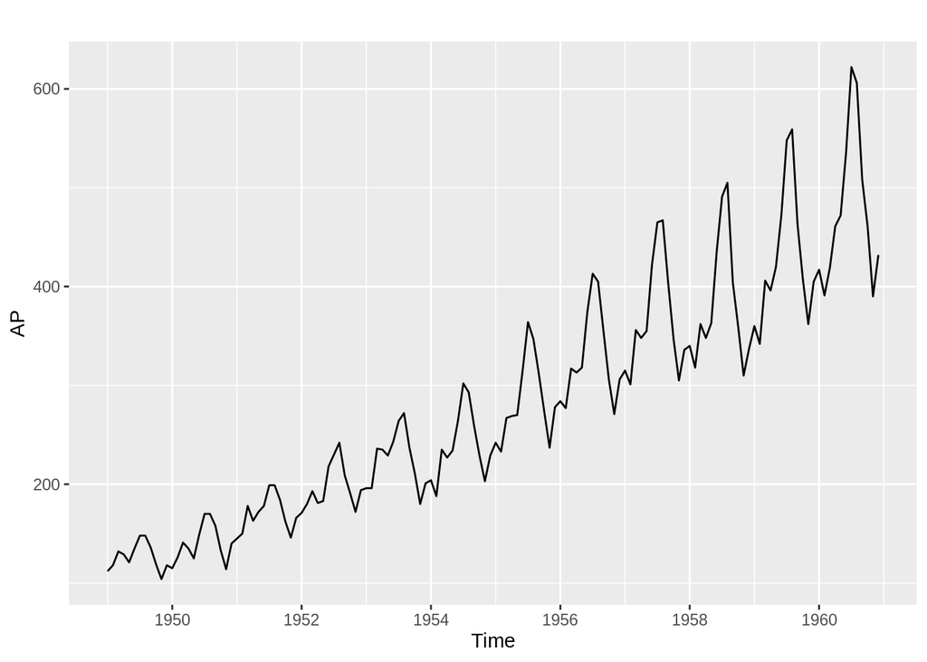

```r
autoplot(AP)
```

Often, we’ll have time series data that has multiple variables. For example, the built-in `fpp2::arrivals` data set has time series data for “quarterly international arrivals (in thousands) to Australia from Japan, New Zealand, UK and the US. 1981Q1 - 2012Q3.” So this time series data has two variables (over and above the time stamp data) - (1) arrivals in thousands and (2) country.

```r
head(arrivals)
```

```
##          Japan     NZ     UK     US
## 1981 Q1 14.763 49.140 45.266 32.316
## 1981 Q2  9.321 87.467 19.886 23.721
## 1981 Q3 10.166 85.841 24.839 24.533
## 1981 Q4 19.509 61.882 52.264 33.438
## 1982 Q1 17.117 42.045 53.636 33.527
## 1982 Q2 10.617 63.081 34.802 28.366
```

We can compare the trends across the different variables (countries) either in one plot or use the facetting option to separate the plots:

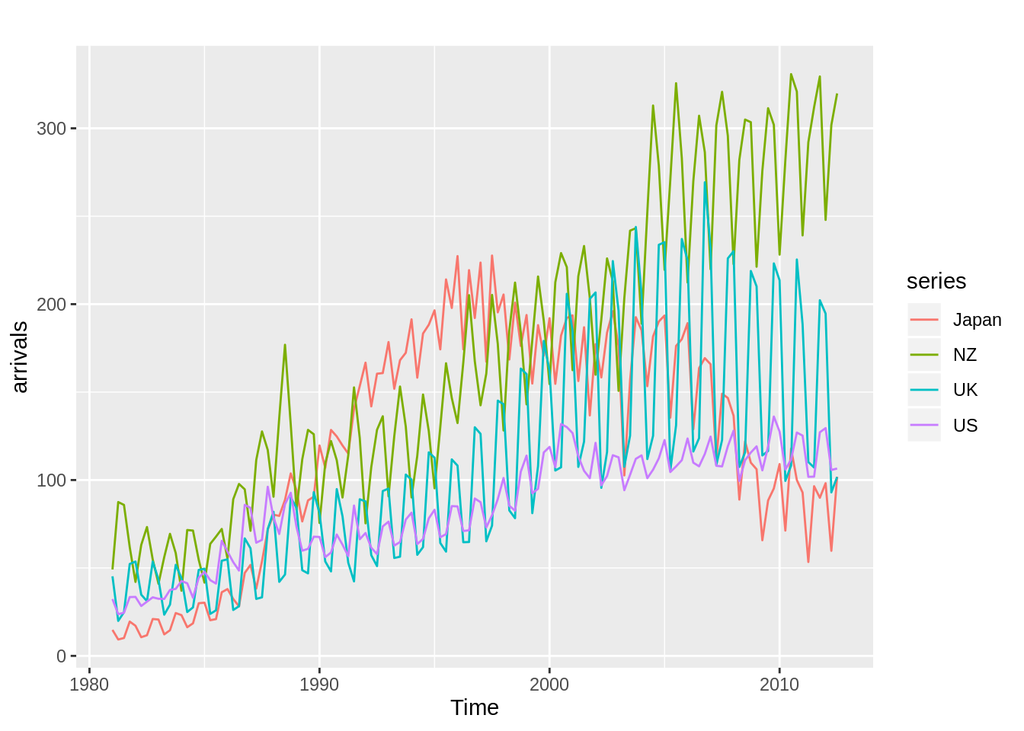

```r
# left
autoplot(arrivals)
```

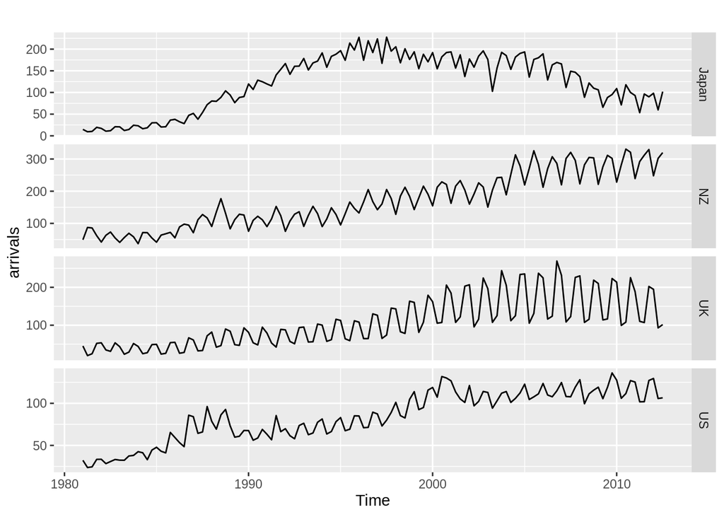

```r
# right
autoplot(arrivals, facets = TRUE)
```

Many of the visualizations in the forecast package are built on top of ggplot2. This allows us to easily add on to these plots with ggplot2 syntax. For example, we can add a smooth trend line and adjust titles:

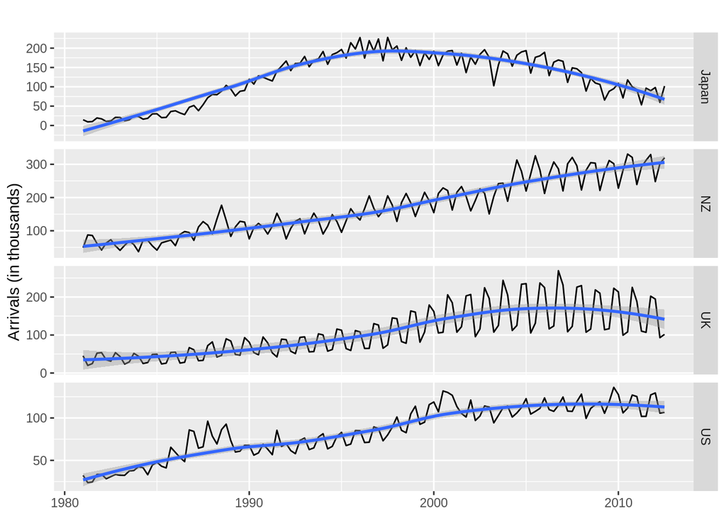

```r
autoplot(arrivals, facets = TRUE) +
  geom_smooth() +
  labs("International arrivals to Australia",
       y = "Arrivals (in thousands)",
       x = NULL)
```

We can index and use many normal functions to assess additional questions such as what was the min, max, or average arrival amount for Japan.

```r
# index for Japan
japan <- arrivals[, "Japan"]

# Identify max arrival amount
summary(japan)
```

```
##    Min. 1st Qu.  Median    Mean 3rd Qu.    Max.
##   9.321  74.135 135.461 122.080 176.752 227.641
```

You can also use the `frequency()` function to get the number of observations per unit time.

```r
frequency(japan)
```

```
## [1] 4
```

In viewing time series plots we can describe different components. We can describe the common components using this quarterly cement production data, `qcement`.

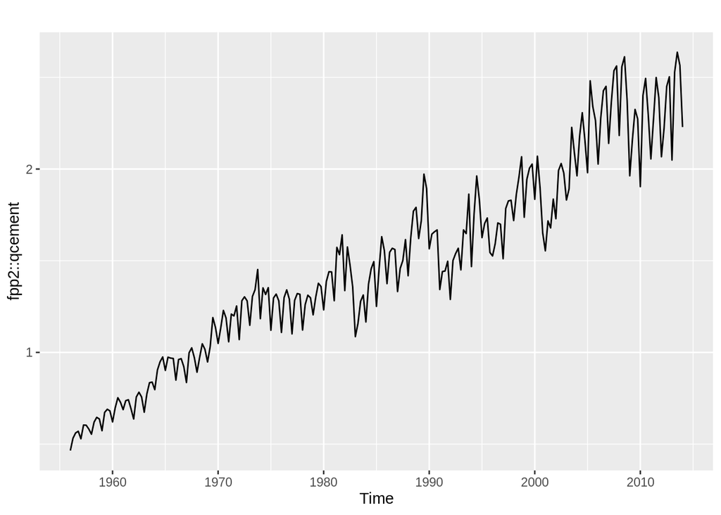

```r
autoplot(fpp2::qcement)
```

How to interpret:

- the **trend** is the long-term increase or decrease in the data. There is an increasing trend in the cement data.
- the **seasonal** pattern occurs when a time series is affected by seasonal factors such as the time of the year or the day of the week. The quarterly cement data above shows seasonality likely induced by the change in weather and its impact on being able to pour cement.
- the **cycle** occurs when the data exhibit rises and falls that are not of a fixed period. These fluctuations are usually due to economic conditions and are often related to the “business cycle”. We can see a few cycles in our cement data in the early ’80s, ’90s, ’00s, and around 2008 - all these date ranges are around economic depressions that occurred.

Let’s return to the `AirPassenger` data set in `forecast`. Decomposing the data into its trend, seasonal, and random error components will give some idea how these components relate to the observed dataset.

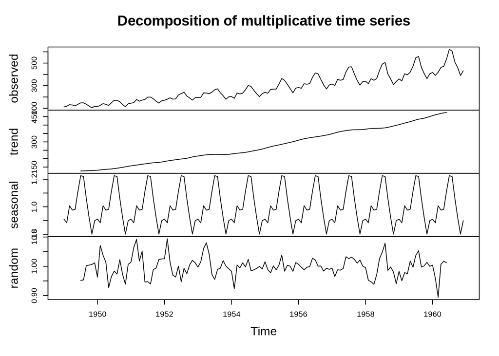

```r
AP.decompM <- decompose(AP, type = "multiplicative")
plot(AP.decompM)
```

Inspecting the trend component in the decomposition plot suggests that the relationship is linear, thus fitting a linear model:

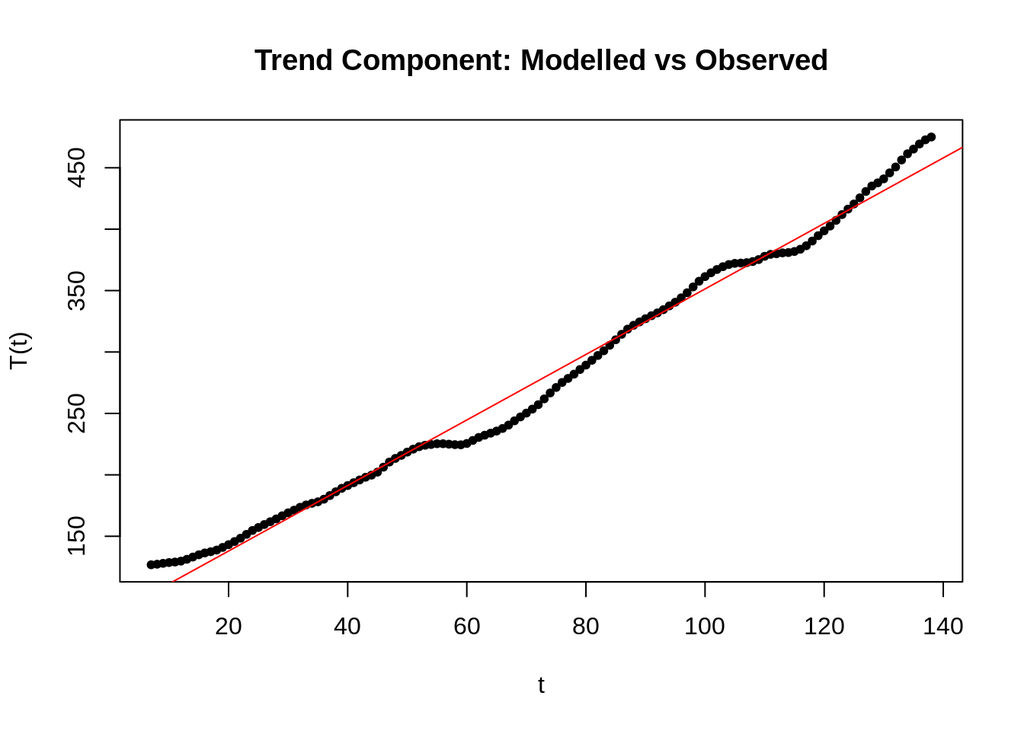

```r
t <- seq(1, 144, 1)
modelTrend <- lm(formula = AP.decompM$trend ~ t)
predT <- predict.lm(modelTrend, newdata = data.frame(t))

plot(AP.decompM$trend[7:138] ~ t[7:138], ylab="T(t)", xlab="t",
     type="p", pch=20, main = "Trend Component: Modelled vs Observed")
lines(predT, col="red")
```

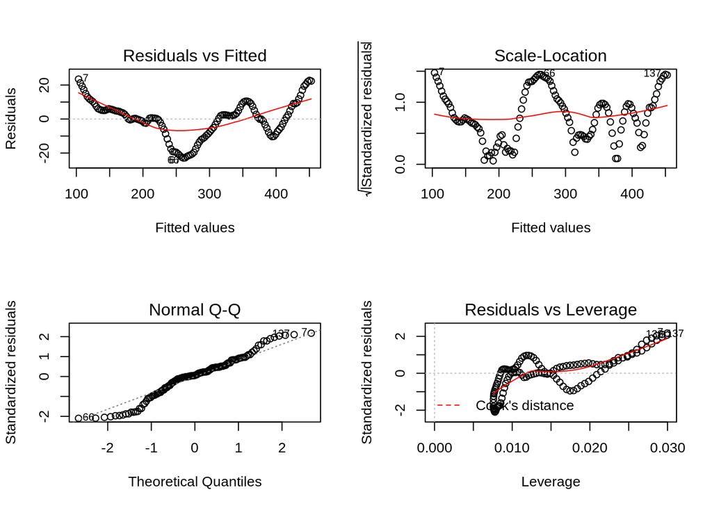

```r
layout(matrix(c(1,2,3,4),2,2))
plot(modelTrend)
```

```r
summary(modelTrend)
```

```
##
## Call:
## lm(formula = AP.decompM$trend ~ t)
##
## Residuals:
##      Min       1Q   Median       3Q      Max
## -22.9162  -6.0845   0.6094   5.8658  23.4748
##
## Coefficients:
##             Estimate Std. Error t value Pr(>|t|)
## (Intercept) 84.64827    2.05100   41.27   <2e-16 ***
## t            2.66694    0.02504  106.50   <2e-16 ***
## ---
## Signif. codes:  0 '***' 0.001 '**' 0.01 '*' 0.05 '.' 0.1 ' ' 1
##
## Residual standard error: 10.96 on 130 degrees of freedom
##   (12 observations deleted due to missingness)
## Multiple R-squared:  0.9887, Adjusted R-squared:  0.9886
## F-statistic: 1.134e+04 on 1 and 130 DF,  p-value: < 2.2e-16
```

Therefore, the relationship between trend and time can be expressed as: $T(t)=2.667t+84.648$

And so for 1961 (time 145 to 156 inc.), the trend component (T) is:

```r
Data1961 <- data.frame("T" = 2.667*seq(145, 156, 1) + 84.648, S=rep(0,12), e=rep(0,12),
                       row.names = c("Jan", "Feb", "Mar", "Apr", "May", "Jun", "Jul", "Aug", "Sep", "Oct", "Nov", "Dec"))
Data1961
```

|  | T | S | e |
| --- | --- | --- | --- |
| Jan | 471.363 | 0 | 0 |
| Feb | 474.030 | 0 | 0 |
| Mar | 476.697 | 0 | 0 |
| Apr | 479.364 | 0 | 0 |
| May | 482.031 | 0 | 0 |
| Jun | 484.698 | 0 | 0 |
| Jul | 487.365 | 0 | 0 |
| Aug | 490.032 | 0 | 0 |
| Sep | 492.699 | 0 | 0 |
| Oct | 495.366 | 0 | 0 |

[output cut: 2 more lines]

Inspecting the seasonal (S) component of the decomposition reveals:

```r
AP.decompM$seasonal
```

```
##            Jan       Feb       Mar       Apr       May       Jun       Jul
## 1949 0.9102304 0.8836253 1.0073663 0.9759060 0.9813780 1.1127758 1.2265555
## 1950 0.9102304 0.8836253 1.0073663 0.9759060 0.9813780 1.1127758 1.2265555
## 1951 0.9102304 0.8836253 1.0073663 0.9759060 0.9813780 1.1127758 1.2265555
## 1952 0.9102304 0.8836253 1.0073663 0.9759060 0.9813780 1.1127758 1.2265555
## 1953 0.9102304 0.8836253 1.0073663 0.9759060 0.9813780 1.1127758 1.2265555
## 1954 0.9102304 0.8836253 1.0073663 0.9759060 0.9813780 1.1127758 1.2265555
## 1955 0.9102304 0.8836253 1.0073663 0.9759060 0.9813780 1.1127758 1.2265555
## 1956 0.9102304 0.8836253 1.0073663 0.9759060 0.9813780 1.1127758 1.2265555
## 1957 0.9102304 0.8836253 1.0073663 0.9759060 0.9813780 1.1127758 1.2265555
## 1958 0.9102304 0.8836253 1.0073663 0.9759060 0.9813780 1.1127758 1.2265555
## 1959 0.9102304 0.8836253 1.0073663 0.9759060 0.9813780 1.1127758 1.2265555
## 1960 0.9102304 0.8836253 1.0073663 0.9759060 0.9813780 1.1127758 1.2265555
##            Aug       Sep       Oct       Nov       Dec
## 1949 1.2199110 1.0604919 0.9217572 0.8011781 0.8988244
## 1950 1.2199110 1.0604919 0.9217572 0.8011781 0.8988244
## 1951 1.2199110 1.0604919 0.9217572 0.8011781 0.8988244
## 1952 1.2199110 1.0604919 0.9217572 0.8011781 0.8988244
## 1953 1.2199110 1.0604919 0.9217572 0.8011781 0.8988244
## 1954 1.2199110 1.0604919 0.9217572 0.8011781 0.8988244
## 1955 1.2199110 1.0604919 0.9217572 0.8011781 0.8988244
## 1956 1.2199110 1.0604919 0.9217572 0.8011781 0.8988244
## 1957 1.2199110 1.0604919 0.9217572 0.8011781 0.8988244
## 1958 1.2199110 1.0604919 0.9217572 0.8011781 0.8988244
## 1959 1.2199110 1.0604919 0.9217572 0.8011781 0.8988244
## 1960 1.2199110 1.0604919 0.9217572 0.8011781 0.8988244
```

Thus the seasonal (S) component to the new 1961 dataset is:

```r
Data1961$S <- unique(AP.decompM$seasonal)
Data1961
```

|  | T | S | e |
| --- | --- | --- | --- |
| Jan | 471.363 | 0.9102304 | 0 |
| Feb | 474.030 | 0.8836253 | 0 |
| Mar | 476.697 | 1.0073663 | 0 |
| Apr | 479.364 | 0.9759060 | 0 |
| May | 482.031 | 0.9813780 | 0 |
| Jun | 484.698 | 1.1127758 | 0 |
| Jul | 487.365 | 1.2265555 | 0 |
| Aug | 490.032 | 1.2199110 | 0 |
| Sep | 492.699 | 1.0604919 | 0 |
| Oct | 495.366 | 0.9217572 | 0 |

[output cut: 2 more lines]

# Seasonal Plots

There are a few useful ways of plotting data to emphasize seasonal patterns and show changes in these patterns over time. First, a seasonal plot is similar to a time plot except that the data are plotted against the individual “seasons” in which the data were observed.

Looking at the quarterly cement production data, `qcement`, we can produce a seasonal plot with `ggseasonplot()`:

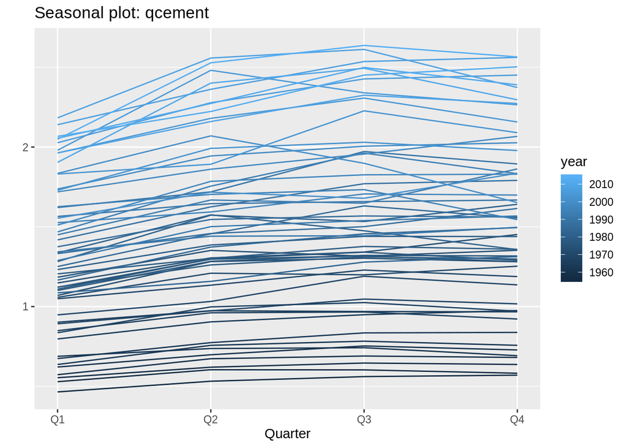

```r
ggseasonplot(qcement, year.labels=FALSE, continuous=TRUE)
```

A seasonal plot allows the underlying seasonal pattern to be seen more clearly, and can be useful in identifying years in which the pattern changes. Here, we see that cement production has consistently increased over the years as the lower (darker) lines represent earlier years and the higher (lighter) lines represent recent years. Also, we see that cement production tends to be the lowest in Q1 and typically peaks in Q3 before leveling off or decreasing slightly in Q4.

A particular useful variant of a season plot uses polar coordinates, where the time axis is circular rather than horizontal. Here, we plot the a10 data with the conventional seasonal plot versus a polar coordinate option to illustrate this variant. Both plots illustrate a sharp decrease in values in Feb and then a slow increase from Apr-Jan.

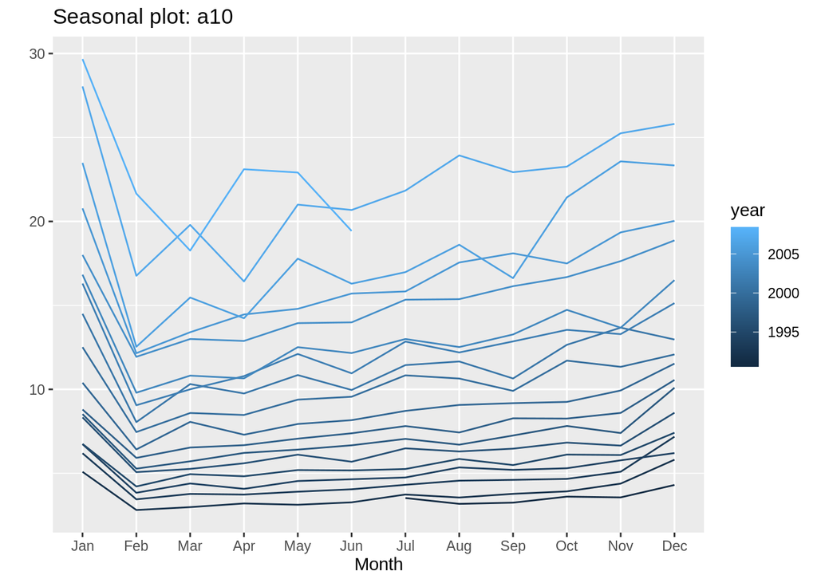

```r
# left
ggseasonplot(a10, year.labels=FALSE, continuous=TRUE)
```

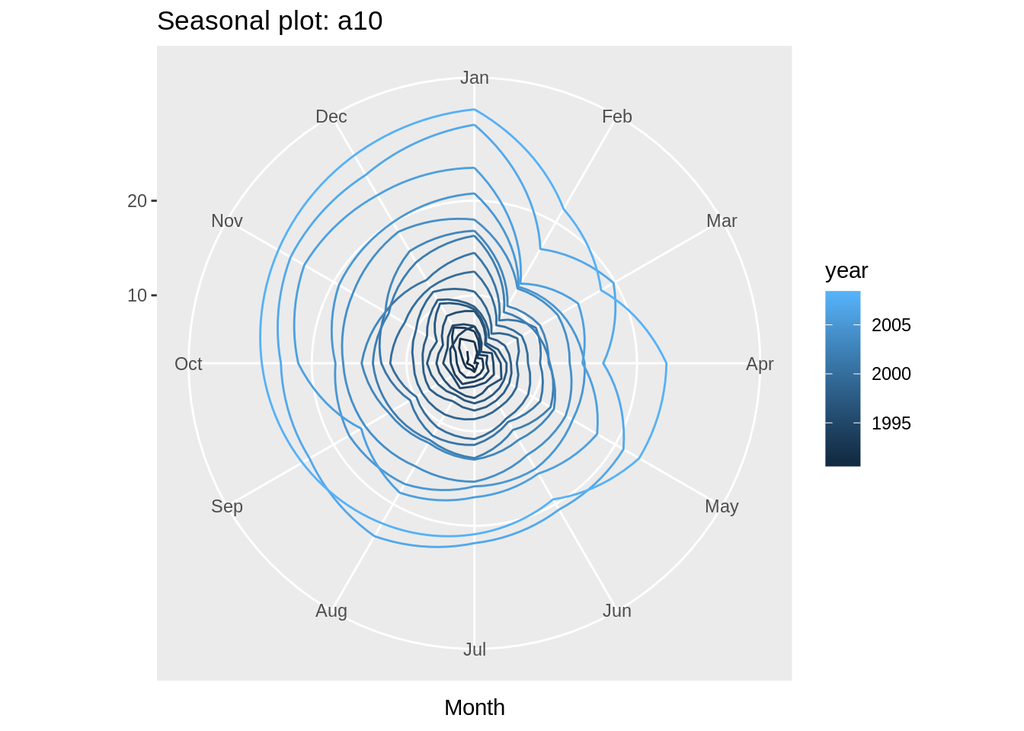

```r
#right
ggseasonplot(a10, year.labels=FALSE, continuous=TRUE, polar = TRUE)
```

An alternative plot that emphasizes the seasonal patterns is where the data for each season (quarter in our example) are collected together in separate mini time plots. A subseries plot produced by `ggsubseriesplot()` creates mini time plots for each season. Here, the mean for each season is shown as a blue horizontal line.

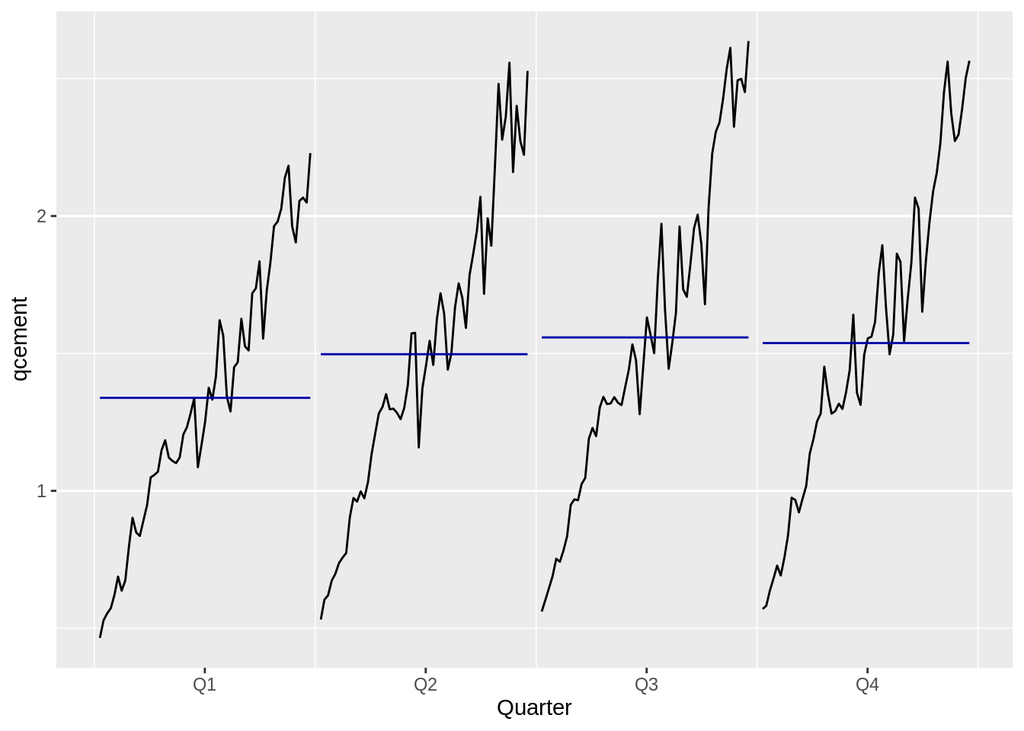

```r
ggsubseriesplot(qcement)
```

This form of plot enables the underlying seasonal pattern to be seen clearly, and also shows the changes in seasonality over time. It is especially useful in identifying changes within particular seasons.

# Autocorrelation

Another way to look at time series data is to plot each observation against another observation that occurred some time previously. For example, you could plot $y_t$ against $y_{t−1}$ . This is called a lag plot because you are plotting the time series against lags of itself. The `gglagplot()` function produces various types of lag plots.

The correlations associated with the lag plots form what is called the “autocorrelation function”.

Autocorrelation is the correlation of a time series with a delayed copy of itself.

Now we look at the **total quarterly beer production in Australia** (in megalitres) from 1956:Q1 to 2010:Q2. The data are available in the `fpp2::ausbeer` time series data.

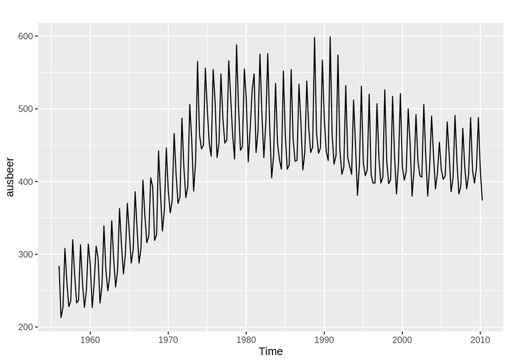

```r
# autoplot of the beer data
autoplot(ausbeer)
```

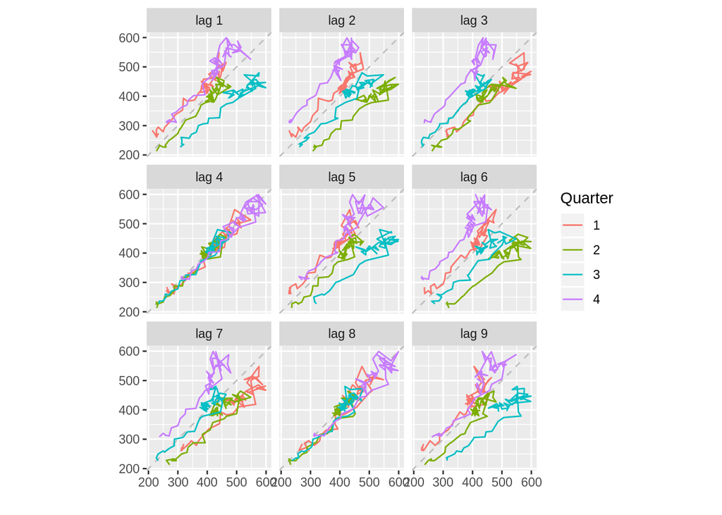

```r
#lag plot of the beer data
gglagplot(ausbeer)
```

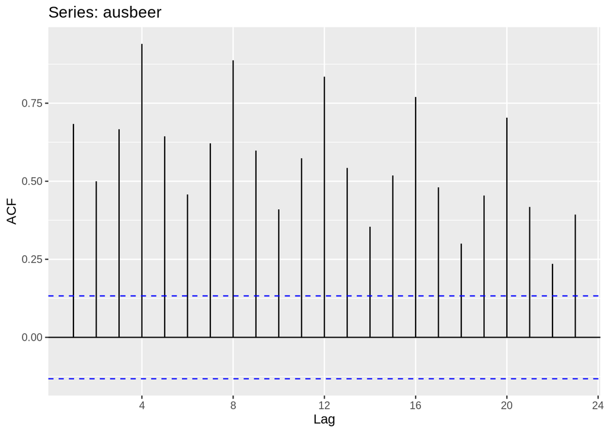

```r
#ACF plot of the beer data
ggAcf(ausbeer)
```

The middle plot provides the bivariate scatter plot for each level of lag (1-9 lags). The bottom plot provides a condensed plot of the autocorrelation values for the first 23 lags. This shows that the greatest autocorrelation values occur at lags 4, 8, 12, 16, and 20. We can adjust the `gglagplot` to help illustrate this relationship.

Here, we create a scatter plot for the first 16 lags.

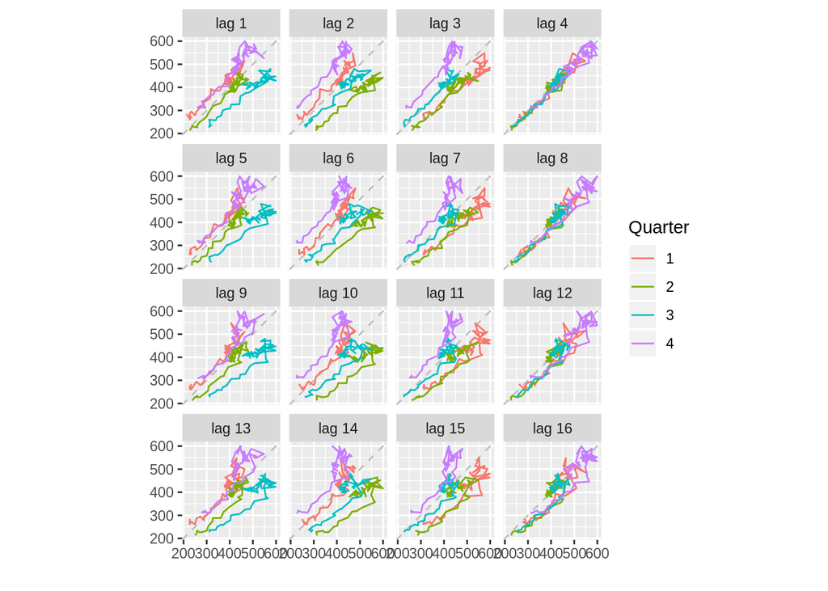

```r
gglagplot(ausbeer,16)
```

If you look at the right-most column (lags 4, 8, 12, 16) you can see that the relationship appears strongest for these lags, thus supporting our far right plot above.

We can see that the autocorrelation for the two strongest lags (4 and 8) is 0.94 and 0.887:

```r
acf(ausbeer, plot = FALSE)
```

```
##
## Autocorrelations of series 'ausbeer', by lag
##
##  0.00  0.25  0.50  0.75  1.00  1.25  1.50  1.75  2.00  2.25  2.50  2.75  3.00
## 1.000 0.684 0.500 0.667 0.940 0.644 0.458 0.621 0.887 0.598 0.410 0.574 0.835
##  3.25  3.50  3.75  4.00  4.25  4.50  4.75  5.00  5.25  5.50  5.75
## 0.543 0.354 0.519 0.770 0.481 0.300 0.454 0.704 0.418 0.236 0.393
```

### A simplified approach to thinking about time series features and autocorrelation

**Trends** induce positive correlations in the early lags.

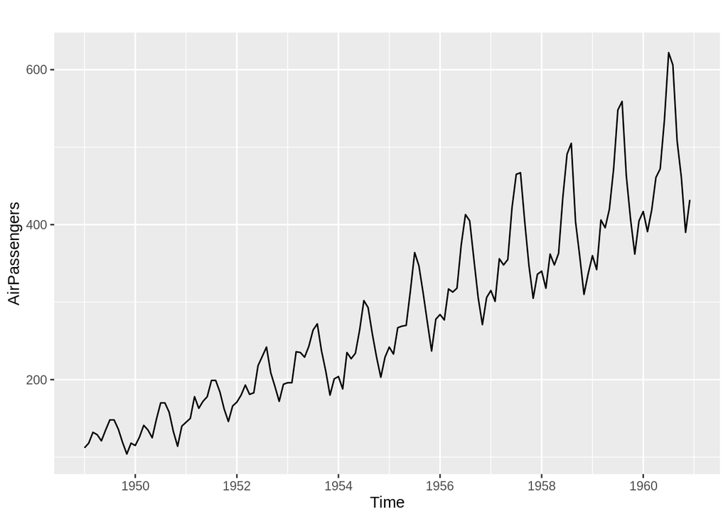

```r
autoplot(AirPassengers)
```

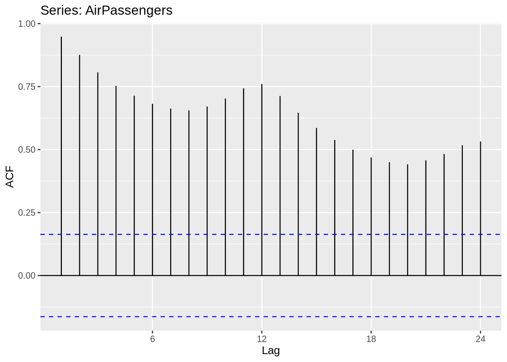

```r
ggAcf(AirPassengers)
```

**Seasonality** will induce peaks at the seasonal lags. Think about the holidays, each holiday will have certain products that peak at that time each year and so the strongest correlation will be the values at that same time each year.

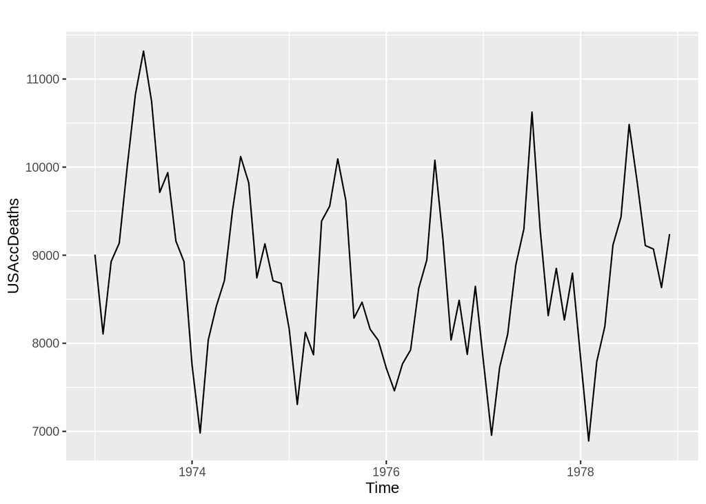

```r
autoplot(USAccDeaths)
```

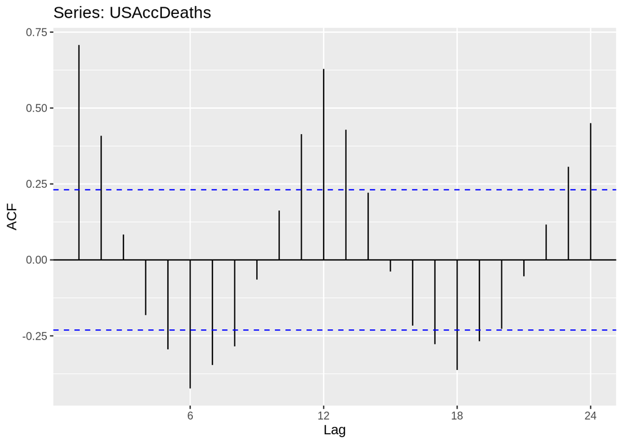

```r
ggAcf(USAccDeaths)
```

**Cyclicity** induces peaks at the average cycle length. Here we see that there tends to be cyclic impact to the mink population every 10 years.

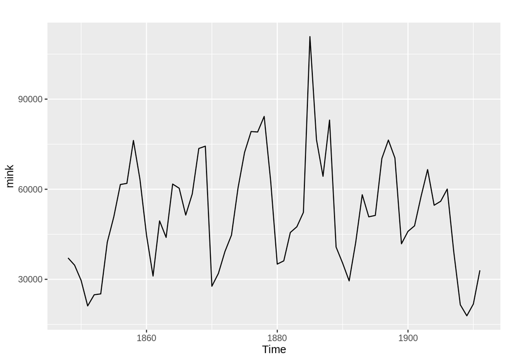

```r
autoplot(mink)
```

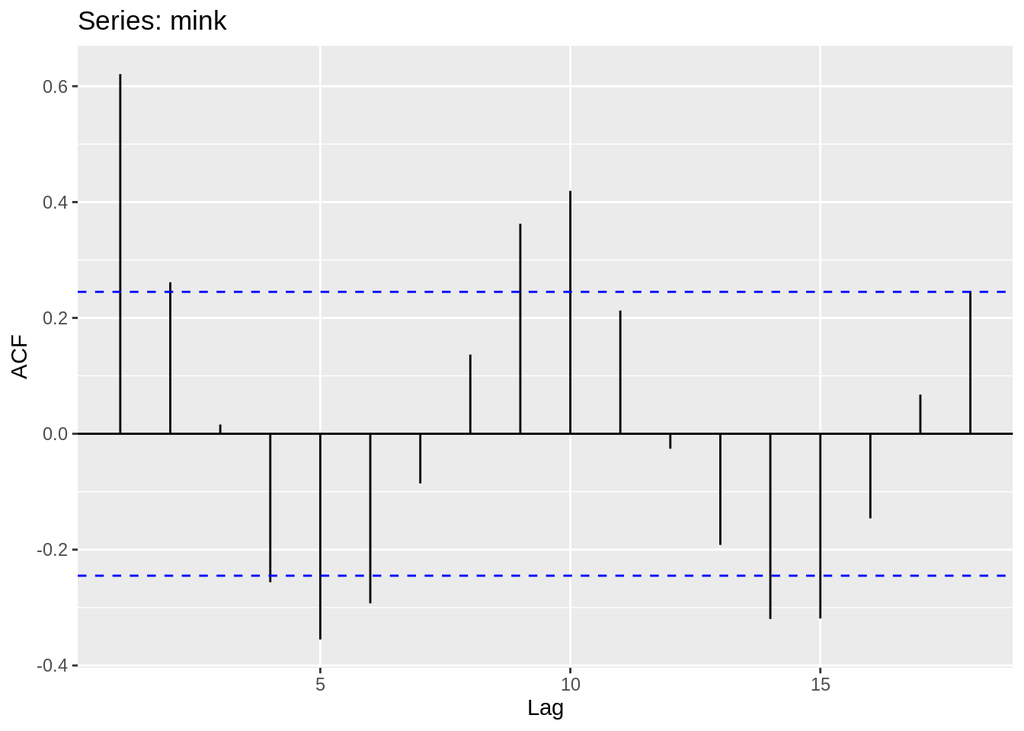

```r
ggAcf(mink)
```

# White Noise

Time series that show no autocorrelation are called “white noise”. For example, the following plots 36 random numbers and illustrates a white noise series. This data is considered idependent and identically distributed (“iid”) because there is no trend, no seasonality, no autocorrelation…just randomness.

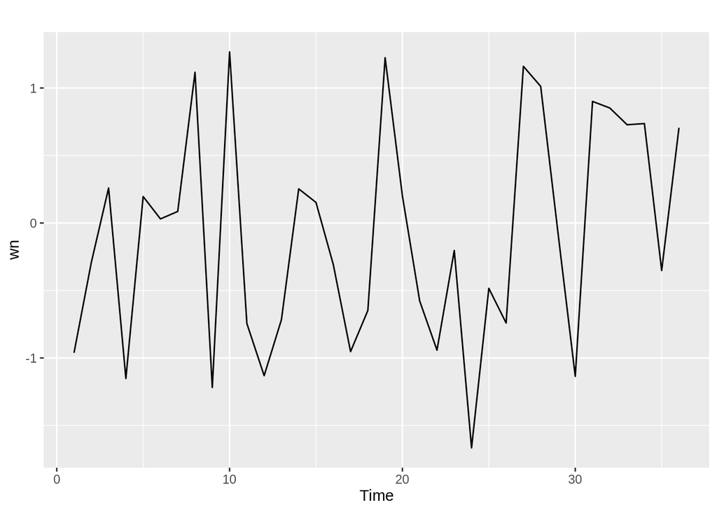

```r
set.seed(3)
wn <- ts(rnorm(36))
autoplot(wn)
```

For white noise series, we expect each autocorrelation to be close to zero.

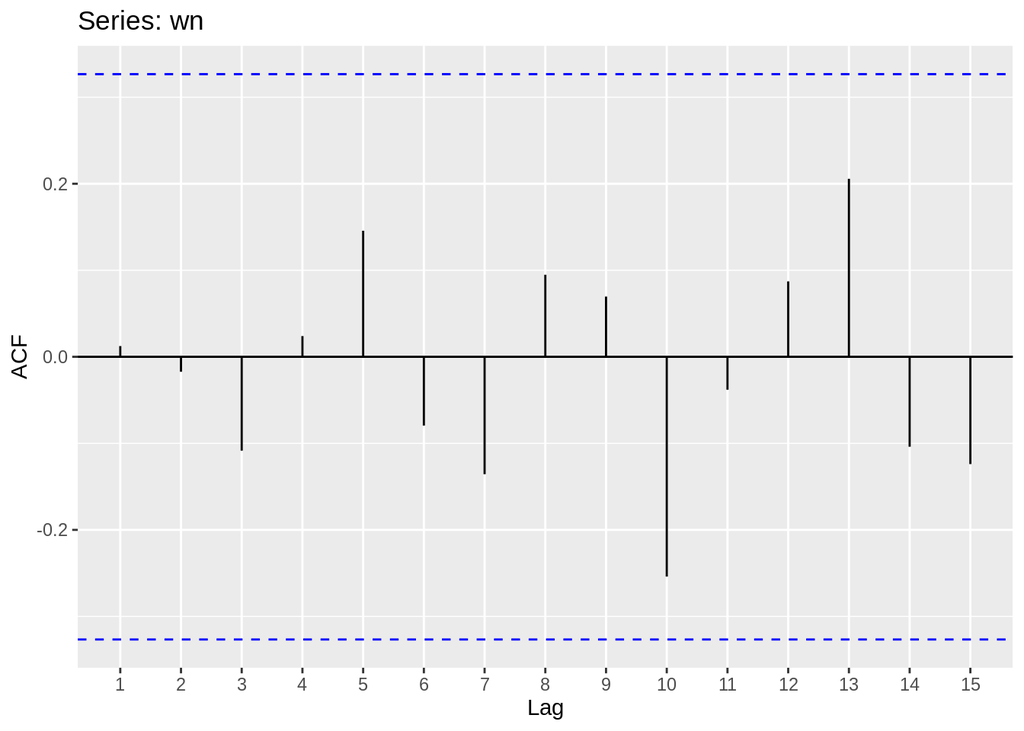

```r
ggAcf(wn)
```

Assessing autocorrelation can be quite useful for data sets where trends and seasonalities are hard to see. For example, the following displays the monthly number of pigs slaughtered in Victoria, Australia from 1990-1995. There may be a slight trend over time but it is unclear.

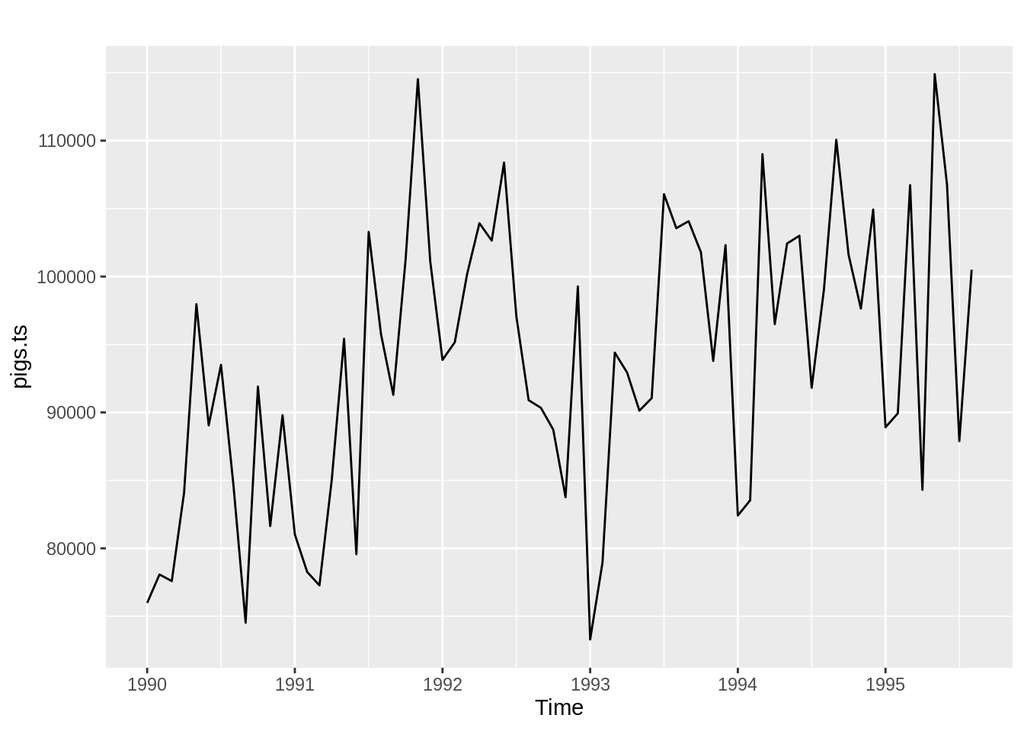

```r
pigs.ts <- ts(pigs[121:188], start = c(1990, 1), frequency = 12)

autoplot(pigs.ts)
```

However, looking at the ACF plot makes the feature more clear. There is more information in this data then the plain time series plot provided. We see that the first three lags clearly exceed the blue line suggesting there is possibly some signal in this time series component that can be used in a forecasting approach.

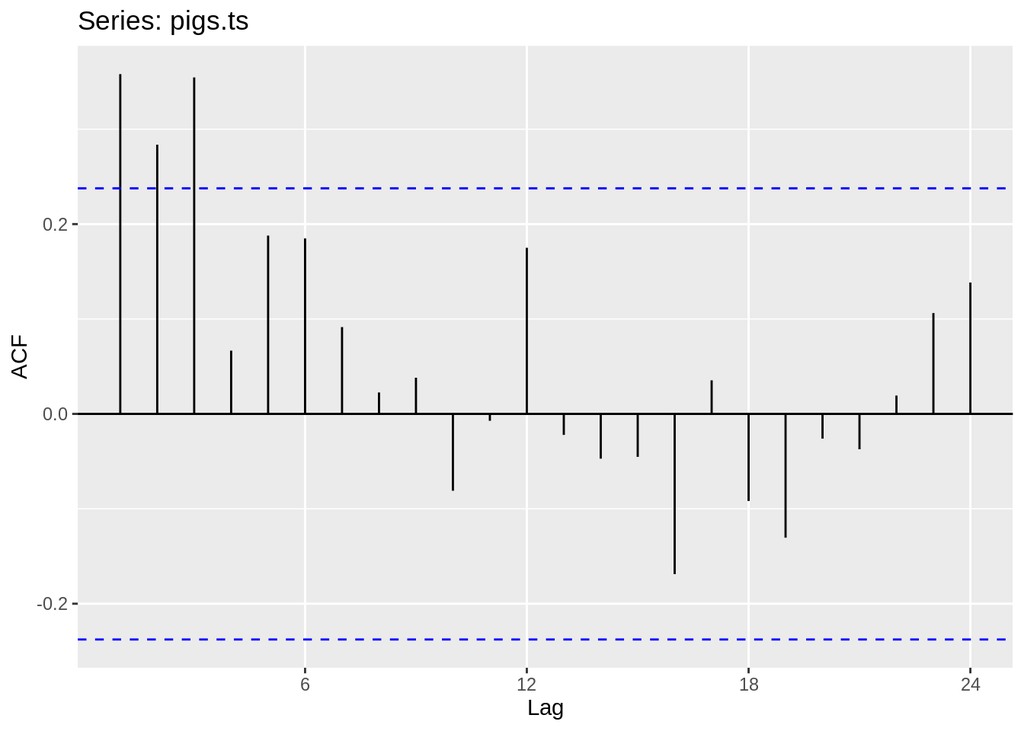

```r
ggAcf(pigs.ts)
```

The ACF plots test if an individual lag autocorrelation is different than zero. An alternative approach is to use the Ljung-Box test, which tests whether any of a group of autocorrelations of a time series are different from zero. In essence it tests the “overall randomness” based on a number of lags. If the result is a small p-value than it indicates the data are probably not white noise.

Here, we perform a Ljung-Box test on the first 24 lag autocorrelations:

```r
Box.test(pigs, lag = 24, fitdf = 0, type = "Lj")
```

```
##
##  Box-Ljung test
##
## data:  pigs
## X-squared = 634.15, df = 24, p-value < 2.2e-16
```

The resulting p-value is significant at $p < 2.2e^{-16}$ so this supports our above statement that it’s likely this is not purely white noise and that some time series information exists in this data.

### Notes on using R Notebook: